# Introduction to R

D. Dubois

**Content**

- Introduction and installation
- Rstudio
- Data Types and Structures
- Dataset Preparation
- Dataset Manipulation
- Descriptive Statistics
- Data Visualization
- Multivariate Analysis
- Dimensionality Reduction and Cluster Analysis
- Sources

Slides: https://www.duboishome.info/dimitri/cours/R

# Presentation and installation of R

ℹ️ R was created by Ross Ihaka and Robert Gentleman at the University of Auckland, New Zealand, in the early 1990s. The development of R was motivated by the desire for an open-source statistical computing and graphics environment that was accessible to researchers and students. **The name “R” was partly derived from the first letters of the creators’ first names, Ross and Robert, and also as a play on the name of the S programming language**, from which R was conceived as an implementation.

Ross Ihaka, a statistician, and Robert Gentleman, who also has a background in statistics, were both faculty members at the University of Auckland when they began working on R. Their collaboration aimed to create a software environment for their students that was not only free but also flexible enough to perform a wide range of statistical analyses and graphical representations.

The initial release of R to the public occurred in 1995, and it quickly gained popularity in the statistical computing community due to its open-source nature, allowing users to modify, improve, and distribute the software. **The Comprehensive R Archive Network (CRAN) was established as a repository of R and its packages**, facilitating the contribution and sharing of code by users worldwide.

**Strengths**

- free and open source
- multi-platform
- extensive package ecosystem
- interpreted, i.e. code can be easily executed
- variety of tools for manipulating and transforming data (tidyverse packages)
- high-quality graphics and visualizations, with a large number of parameters for customizations
- an active community of users

**Weaknesses**

- not easy to learn at first
- more a Command Line Interface (CLI) than a Graphical User Interface (GUI)

**Install**

- R : https://cran.r-project.org/
- RStudio : https://posit.co/

# RStudio

- Integrated Development Environment (IDE) dedicated to R
- user-friendly interface for R
- free, open source and multi-platform

[figure not shown]

**3 areas**

- the R interpreter (console) and terminal
- the session environment, with the list of variables/objects, their type and their value. Also an history tab with the list of past commands
- the help area, with also the list of R packages

## The R interpreter

- interprets the code and displays the results
- the top and bottom arrows to navigate in the history of commands
- “Enter” key to execute the current line of code

```r
10 * 2
```

```
[1] 20
```

- to store a value one must create a variable and assign the value
- the assignment operator is `<-`

```r
x <- 10
```

- it means that we assign the value “10” to the variable “x”
- the variable “x” can be called later, to display its value or make calculations

```r
x
```

```
[1] 10
```

ℹ️ The use of `<-` as the assignment operator in R is rooted in its history and the influence of the S language.  
While `<-` is the traditional and recommended assignment operator in R, `=` is also supported for assignment.  
However, the use of `<-` is encouraged in the R community and in coding standards for clarity and tradition.

- once a variable (or an object) is created, it appears in the “Environment” tab
- lines of codes that have been executed appear in the “History” tab (double click on the line to run it in the console)
- one can create as many objects as needed, and make calculations with these objects

```r
y <- 100
x + y
```

```
[1] 110
```

- variables / objects names can contain letters, numbers and special characters “.” and “_”
- but can’t start by a number or a special character
- no accent
- case sensitive, which means that x and X are two different objects

## Project

- allows you to organize files, data, and code associated with a specific task (e.g. data analysis)
- it sets the working directory, i.e. the directory in which files will be stored (and loaded) by default for the project
- avoids to write the absolute path of files each time we need to read or write a file
- to create a new project : File/New Project
- either create a new folder on the computer or use an existing one

File/New Project

[figure not shown]

New Project

## Package `here`

- Using absolute paths like `setwd("C:/Users/Name/Documents/Project")` makes the code non-portable (it will fail on any other computer).
- The `here` package creates paths relative to the project’s root directory, regardless of where your script or Quarto file is located.
- With `here`, the project directory can be stored on the cloud and shared with others without path issues.

```r
library(here)
library(readr)

# This works on Windows, Mac, or Linux, for any user
my_data <- read_csv(here("data", "raw_data.csv"))
```

💡 Always use RStudio Projects (`.Rproj`) combined with `here`. This ensures that your entire research environment is a self-contained unit that can be shared via GitHub or OSF.

## Package Versioning with `renv`

- `renv` creates a private library for your project, isolated from the rest of your system.
- **Key Workflow**:
  - `renv::init()`: Set up the project library.
  - `renv::snapshot()`: Save the exact versions of all packages used.
  - `renv::restore()`: Replicate the environment on a colleague’s computer.

```r
install.packages("renv")
renv::init()
# install needed packages
renv::snapshot()  # update the snapshot (renv.lock)
```

💡 Including a `renv.lock` file in your data repository (like OSF or Zenodo) is the gold standard for reproducible research.

## Scripts

- console does not store the code once the session is closed
- instead of the console, we write the code in a file, called a script, and run the content of the file in the console. It allows to keep track of the code. To create a new script: File/New File/R Script
- it is a text file, with an `*.R` extension
- to run the code into the console, either `Run` or `Ctrl + Enter`

## Notebooks

- a notebook is a document that allows the user to mix executable code, visualizations, and explanatory text in a single, interactive document
- can be exported in html or pdf
- easy to read, share, reproduce and maintain

File/New File/R Notebook

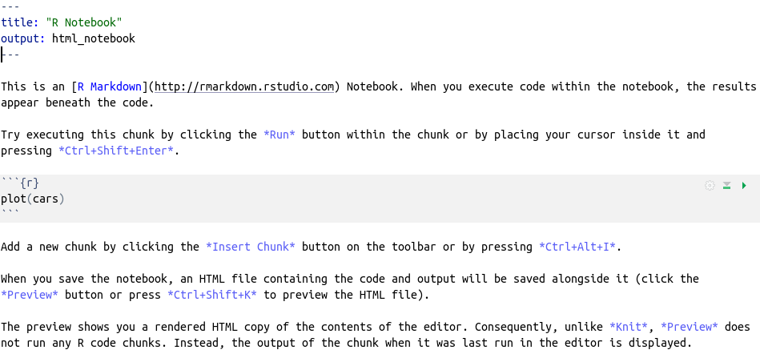

- title can be changed
- do not modify the output
- the text after the three dashes can be deleted, it only serves to explain how the notebooks work
- block with code are called `chunks`
- insert/R to insert a new chunk (or `Ctrl + alt + i`)
- inside the chunk, `Ctrl + Enter` to execute the current line of code, or `Ctrl + Maj + Enter` to execute the whole chunk
- the ouput of the chunk is displayed just below the chunk
- as soon as you save the notebook, an html file is created

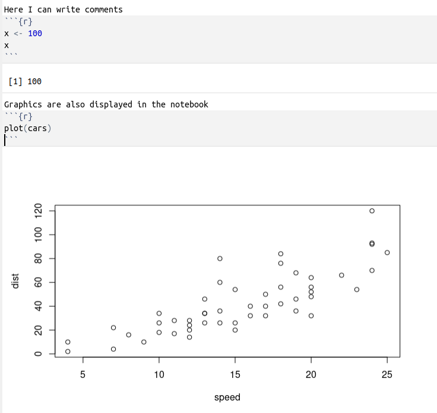

## Quarto

- Quarto is the multi-language, next-generation version of Notebooks (Jupyter and R Markdown).
- It is independent of R, meaning it works seamlessly with Python, Julia, and Observable JS as well.
- It allows you to create high-quality articles, reports, presentations (like this one!), and websites.
- Extension: `.qmd` instead of `.Rmd`.

ℹ️ More information: https://quarto.org/

**Why use Quarto for Research?**

- *Polyglotte*: Python, R, Julia and OJS in the same document
- *Native Citations*: Easily manage bibliographies (`.bib`) and cross-references (Figures, Tables, Equations).
- *Consistent Output*: Switch between PDF (LaTeX), HTML, and MS Word without changing your code.
- *Advanced Layouts*: Create complex multi-column layouts or tabsets for your analysis.
- *Publication Ready*: Many scientific journals now provide Quarto templates for direct submission.

## Markdown

- text in the notebook can be written with the markdown markup language
- simple syntax to create headings, emphasis, lists, links, and other basic text formatting
- simplified html
- RStudio offer a quick guide : Help/Markdown Quick Reference

## Packages

- set of user-contributed codes and functions that extend the functionality of R
- easy to install with `install.packages()` or tab `Packages` and `Install`
- developed and maintained by the R community
- handled and stored in the CRAN network (Comprehensive R Archive Network)
- write the name of the package and click on `Install`
- to be able to use the package it must be loaded with `library(package_name)`
- by convention, the `library(xxx)` should be placed at the top of the script/notebook

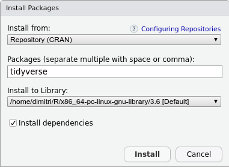

## 💻 Practice

- create a new project
- create a `renv` environment
- create a new Quarto notebook
- install the packages `here`, `tidyverse` and `questionr`
- in the first chunk of the quarto document, load `here`, `tidyverse` and `questionr`

ℹ️ The `questionr` package is a useful tool designed primarily for social scientists, providing a set of functions to facilitate the analysis of survey data.

# Data types and structures

## Types of data

- Numeric (whole numbers and decimal numbers)
- Logical (TRUE/FALSE values)
- Character (textual data)
- Factor (categorical data)
- NA : missing value (Not Available)

and also

- Complex (complex numbers with real and imaginary parts)
- POSIXct (date and time values)

`typeof(objet)` to display the type of an object

```r
a <- "hello R world !"
typeof(a)
```

```
[1] "character"
```

## Missing Values

- NA (Not Available): A placeholder for a missing value.
- NULL: Represents the “empty set”. It has length 0 and is often used to remove elements from a list.
- NaN (Not a Number): Result of undefined math (e.g., 0/0).

## The vector

- in R, every piece of data is a vector. Even a single number is a vector of length 1.
- it’s a one-dimensional array
- can be created with the `c()` function, where `c()` means *concatenate* or *combine*

```r
vec_1 <- c(1, 10, 15)
vec_1
```

```
[1]  1 10 15
```

```r
(vec_2 <- c("hello", "world"))
```

```
[1] "hello" "world"
```

💡 The parenthesis in the chunk execute the line of code and displays the output

Mathematical operations on vectors are applied element-wise.

```r
height <- c(1.75, 1.54, 1.85, 1.92)
height * 100
```

```
[1] 175 154 185 192
```

```r
weight <- c(72, 59, 110, 95)
(imc <- weight / height ^ 2)
```

```
[1] 23.51020 24.87772 32.14025 25.77040
```

### Functions to create a vector

- to create empty vectors: numeric(), character(), logical()
- if an integer as argument to the function it defines the size of the vector, with default values: 0 for numeric, “” for character and FALSE for logical

```r
numeric(10)
```

```
 [1] 0 0 0 0 0 0 0 0 0 0
```

`:` to create a sequence of numbers that follow each other by an interval of 1

```r
1:10
```

```
 [1]  1  2  3  4  5  6  7  8  9 10
```

`seq()` to create a sequence of numbers with custom start, end and step values

```r
seq(from=0, to=20, by=4)
```

```
[1]  0  4  8 12 16 20
```

```r
# seq(0, 20, 4)
```

`rep()` to repeat a vector

```r
rep(1:5, times=2)
```

```
 [1] 1 2 3 4 5 1 2 3 4 5
```

💡 *Notes:*

- `seq()` and `rep()` have other arguments, see the help with `?seq` and `?rep`.
- There exists functions to generate vectors with random values: `rnorm`, `runif`, `rbinom`, `rpois` etc.

### Implicit Coercion

- R forces vectors to be of a single type. If you mix types, R will “coerce” them to the most flexible type.
- Hierarchy (from least to most flexible): logical $\rightarrow$ integer $\rightarrow$ double $\rightarrow$ character.

```r
mix <- c(TRUE, 1L, 2.5, "Data")
typeof(mix)
```

```
[1] "character"
```

→ A single “None” string in a column of numbers will turn the entire variable into character.

### Indexation system

- elements can be selected from a vector using square brackets `[]`
- the first element is indexed as 1
- to select a single element, provide its index inside the brackets

```r
height <- c(1.75, 1.54, 1.85, 1.92)
```

```r
height[1]
```

```
[1] 1.75
```

ℹ️ The decision to start indexing from 1 in R :

*Ease for Non-programmers*: Many users of R come from academic backgrounds in statistics, mathematics, and various fields of science, where 1-based indexing is the norm. Starting indexes at 1 can be more intuitive for individuals who are not primarily trained in computer science but are using R for data analysis, statistical modelling, and research.

*Alignment with Theoretical Concepts*: In statistical formulas and mathematical expressions, indexes typically start at 1. Using 1-based indexing in R makes it easier to translate these formulas and expressions directly into code without having to adjust the index values.

to select multiple elements, provide a vector of indices inside the brackets

```r
height[c(1, 3)]
```

```
[1] 1.75 1.85
```

slicing can be used to select a range of elements

```r
height[2:4]
```

```
[1] 1.54 1.85 1.92
```

### The factor

- a categorical variable (gender, species, political affiliation etc.)
- created by calling the factor function to a vector of values
- R assigns a label to each category and assigns an integer level (1 for the first level, 2 for the second level, and so on) → factors are integers with labels

```r
gender <- c("M", "F", "M", "M", "F", "F")
gender
```

```
[1] "M" "F" "M" "M" "F" "F"
```

```r
typeof(gender)
```

```
[1] "character"
```

```r
gender <- factor(gender)
gender
```

```
[1] M F M M F F
Levels: F M
```

```r
typeof(gender)
```

```
[1] "integer"
```

```r
str(gender)
```

```
 Factor w/ 2 levels "F","M": 2 1 2 2 1 1
```

possible to change the names of the levels with the levels function

```r
levels(gender) <- c("Female", "Male")
str(gender)
```

```
 Factor w/ 2 levels "Female","Male": 2 1 2 2 1 1
```

### Useful Functions

A function is called by its name, followed by parentheses containing zero, one, or multiple arguments.

- `?function_name` (or `help("function_name")`) to display the function’s help documentation.
- Some functions have required arguments and optional arguments.
- In the function signature, required arguments have no default value, while optional arguments do.
- For example, the mean function has one required argument and an optional argument na.rm, which allows ignoring missing values (NA) when calculating the mean.
- `length(v)`: returns the length of v (number of elements).
- `mean(v)`: returns the mean of v.
- `min(v)`, `max(v)`: return the minimum (maximum) value of v.
- `sum(v)`: returns the sum of the values in v.
- `range(v)`: returns a vector containing the minimum and maximum values.
- `unique(v)`: returns a vector derived from v with duplicate values removed.

```r
mean(height)
```

```
[1] 1.765
```

```r
min(height)
```

```
[1] 1.54
```

### Combining vectors

With `rbind` and `cbind`

- `rbind` to combine vectors by row
- `cbind` to combine vectors by column

```r
(v1 <- c(1, 2, 3))
```

```
[1] 1 2 3
```

```r
(v2 <- c(4, 5, 6))
```

```
[1] 4 5 6
```

**`rbind`**

```r
(rbind(v1, v2))
```

```
   [,1] [,2] [,3]
v1    1    2    3
v2    4    5    6
```

**`cbind`**

```r
(cbind(v1, v2))
```

```
     v1 v2
[1,]  1  4
[2,]  2  5
[3,]  3  6
```

### Calculating averages on combined vectors

With `rowMeans` and `colMeans`

- `rowMeans` to calculate the mean by row
- `colMeans` to calculate the mean by column

```r
v1 <- seq(1, 10, by=2)
v2 <- seq(2, 20, by=4)
(mat <- cbind(v1, v2))
```

```
     v1 v2
[1,]  1  2
[2,]  3  6
[3,]  5 10
[4,]  7 14
[5,]  9 18
```

```r
rowMeans(mat)
```

```
[1]  1.5  4.5  7.5 10.5 13.5
```

```r
colMeans(mat)
```

```
v1 v2
 5 10
```

💡 There are also rowSums and colSums for calculating sums.

### 💻 Practice

1. calculate the absolute difference of income between the husband and the wife in each household (function `abs`)
2. calculate the total income of the households
3. calculate the income per person in each household

```r
husband_income <- c(1200, 1180, 1750, 2100)
wife_income <- c(1450, 1870, 1690, 0)
household_people <- c(4, 2, 3, 2)
```

**Exercice 2.** With the vector below:

1. what is the type of the vector
2. change the vector as a categorical variable
3. display the levels and the associated integers
4. change the level “Ph.D” to “PhD”

```r
education_levels <- c("Bachelor", "Master", "Ph.D")
(education <- sample(education_levels, 10, replace = TRUE))
```

```
 [1] "Bachelor" "Master"   "Ph.D"     "Master"   "Bachelor" "Ph.D"
 [7] "Master"   "Master"   "Master"   "Bachelor"
```

💡 `sample()` takes a sample of the specified size from the elements of x using either with or without replacement.

**Exercice 3.** With the vectors below, which represent the note of 6 students in 3 disciplines:

1. calculate the average of each student
2. calculate the average in each discipline
3. display the quartiles of the python discipline

```r
python <- c(12, 16, 8, 18, 6, 10)
html <- c(14, 9, 13, 15, 17, 11)
bdd <- c(18, 11, 14, 10, 8, 12)
```

## The dataframe

- two-dimensional array (with rows and columns), similar to a spreadsheet
- each column / variable is a vector
- vectors can be of different data type (number, character, logical, factor)
- created with the data.frame() function

```r
df1 <- data.frame(
  gender=factor(sample(c("M", "F"), 10, replace=T)),
  age=sample(18: 100, 10, replace=T),
  education=education
  )
df1
```

```
   gender age education
1       F  22  Bachelor
2       M  80    Master
3       M  93      Ph.D
4       M  22    Master
5       F  70  Bachelor
6       M  34      Ph.D
7       M  45    Master
8       F  67    Master
9       M  49    Master
10      F  31  Bachelor
```

We can access to a variable/column/vector in a dataframe with `$`

```r
df1$gender
```

```
 [1] F M M M F M M F M F
Levels: F M
```

```r
df1$gender[c(1, 3)]
```

```
[1] F M
Levels: F M
```

Let’s take an example dataset, `hdv2003`, provided by the `questionr` package that was previously loaded. We load the dataset with the following command:

```r
data("hdv2003")
```

This places the dataset into the working environment. `hdv2003` is a subset of the *Histoire de vie* survey conducted by INSEE in 2003. It contains 2,000 individuals and 20 variables.

Click on the object in the Environment tab to view the data table (you can also use the function View(hdv2003)).

💡 `data()` written in the console displays all available datasets (R core + loaded libraries).

### Useful functions to discover a dataframe

- `names(df)`: displays the column names
- `nrow(df)`: returns the number of rows
- `ncol(df)`: returns the number of columns
- `dim(df)`: returns a vector with the dataset dimensions, i.e., `nrow` and `ncol`
- `names(df)`: returns the variable (column) names
- `str(df)`: displays information about the dataset – each variable with its type and the first few values (if you click on the blue arrow in the environment, it shows the content of `str(df)`)
- `head(df)`: displays the first rows
- `tail(df)`: displays the last rows

```r
dim(hdv2003)
```

```
[1] 2000   20
```

```r
names(hdv2003)
```

```
 [1] "id"            "age"           "sexe"          "nivetud"
 [5] "poids"         "occup"         "qualif"        "freres.soeurs"
 [9] "clso"          "relig"         "trav.imp"      "trav.satisf"
[13] "hard.rock"     "lecture.bd"    "peche.chasse"  "cuisine"
[17] "bricol"        "cinema"        "sport"         "heures.tv"
```

### 💻 Practice

Load the dataset `hdv2003` from package `questionr`

1. display the dimensions of the dataset
2. display the names of the variables
3. display the type of the variables

## The matrix

- a two-dimensional array consisting of elements of the same data type
- elements of a matrix are organized in rows and columns

Creation:

- `matrix(data, nrow, ncol, byrow=FALSE, dimnames=NULL)`
- `diag(n)` : diagonal matrix with `n` ones on the diagonal
- `diag(v)` : diagonal matrix with the vector `v` on the diagonal

```r
# 3x3 matrix with values from 1 to 9
matrix(1:9, nrow = 3, ncol = 3, byrow = TRUE)
```

```
     [,1] [,2] [,3]
[1,]    1    2    3
[2,]    4    5    6
[3,]    7    8    9
```

**Matrix operations**

- `%*%` : matrix product
- `t(mat)` : matrix transpose
- `solve(mat)` : matrix inverse
- `det(mat)` : matrix determinant

ℹ️ *More info:*

- https://r-coder.com/matrix-operations-r/?utm_content=cmp-true
- https://www.statmethods.net/advstats/matrix.html

## The array

- a multi-dimensional data structure that can store data in more than two dimensions
- similar to matrices but are generalized to an arbitrary number of dimensions
- `array()` function to create arrays.
- like matrices, all elements in an array must be of the same data type.

```r
(my_array <- array(1:18, dim = c(3, 3, 2)))
```

```
, , 1

     [,1] [,2] [,3]
[1,]    1    4    7
[2,]    2    5    8
[3,]    3    6    9

, , 2

     [,1] [,2] [,3]
[1,]   10   13   16
[2,]   11   14   17
[3,]   12   15   18
```

## The list

- can contain different types of data / objects
- created using the `list()` function and elements are separated by commas
- similar to a dictionary in other languages (with pairs of key / value)

```r
mylist <- list("my_vector"=1:10, "my_sentence"="Hello world!")
mylist
```

```
$my_vector
 [1]  1  2  3  4  5  6  7  8  9 10

$my_sentence
[1] "Hello world!"
```

an element can be accessed by its name with `$`

```r
mylist$my_vector
```

```
 [1]  1  2  3  4  5  6  7  8  9 10
```

# Dataset preparation

**The tidyverse**

Set of libraries aimed at facilitating the management of the dataset (data cleaning, data wrangling, preprocessing)

`library(tidyverse)`

[figure not shown]

readr (import of data), tibble (new dataframe), forcats (qualitative variables), stringr (for characters), tidyr (data formatting), dplyr (data manipulation), ggplot2 (visualization), purrr (programming)

## The Tibble

- modern version of the data frame
- compared to the dataframe, the tibble
  - has no rownames
  - allows column names with spaces, special characters, numbers etc.
  - is displayed optimally in the console, over a few lines and with some information about each variable
- functions and libraries of the tidyverse accept a dataframe as argument but return a tibble

```r
as_tibble(hdv2003)
```

```
# A tibble: 2,000 × 20
      id   age sexe  nivetud        poids occup qualif freres.soeurs clso  relig
   <int> <int> <fct> <fct>          <dbl> <fct> <fct>          <int> <fct> <fct>
 1     1    28 Femme Enseignement…  2634. Exer… Emplo…             8 Oui   Ni c…
 2     2    23 Femme <NA>           9738. Etud… <NA>               2 Oui   Ni c…
 3     3    59 Homme Derniere ann…  3994. Exer… Techn…             2 Non   Ni c…
 4     4    34 Homme Enseignement…  5732. Exer… Techn…             1 Non   Appa…
 5     5    71 Femme Derniere ann…  4329. Retr… Emplo…             0 Oui   Prat…
 6     6    35 Femme Enseignement…  8675. Exer… Emplo…             5 Non   Ni c…
 7     7    60 Femme Derniere ann…  6166. Au f… Ouvri…             1 Oui   Appa…
 8     8    47 Homme Enseignement… 12892. Exer… Ouvri…             5 Non   Ni c…
 9     9    20 Femme <NA>           7809. Etud… <NA>               4 Oui   Appa…
10    10    28 Homme Enseignement…  2277. Exer… Autre              2 Non   Prat…
# ℹ 1,990 more rows
# ℹ 10 more variables: trav.imp <fct>, trav.satisf <fct>, hard.rock <fct>,
#   lecture.bd <fct>, peche.chasse <fct>, cuisine <fct>, bricol <fct>,
#   cinema <fct>, sport <fct>, heures.tv <dbl>
```

## Loading a dataset

- csv format is a good practice and a standard to share data
- 2 functions: read_csv and read_csv2
- read_csv: “,” as separator and “.” as decimal
- read_csv2: “;” as separator and “,” as decimal

ℹ️ *Notes:*

- There exists also `read_excel`, `read_stata`, `read_sas` etc. to import data from other formats.
- RStudio provides a graphical interface to import data, by clicking on “Import Dataset” in the environment tab

## Exporting data

To export a dataset in a csv file, there exists write_csv and write_csv2.

**Serialization**

- Used to save R objects in R format
- Allows saving multiple R objects in a single file (extension `*.Rdata`)
- Function `save(objects, file="file.Rdata")`
- Function `load("file.Rdata")` to reload the objects into the R session environment

## Renaming variables

- Cleaning Column Names with package `janitor`
- Raw datasets (Excel, Surveys) often have “dirty” column names: spaces, accents, special characters, or inconsistent capitalization.
- d`f$Nom de l'élève ! (en 2024)` is tedious and error-prone.

→ `janitor::clean_names()` automatically converts all column names to snake_case (lowercase, words separated by underscores).

Example :

```r
Before: "First Name", "Age (2024)", "Sexe/Genre"
After: "first_name", "age_2024", "sexe_genre"
```

💡 *Notes:*

`janitor::clean_names()` tells the interpreter to use function `clean_names` from package `janitor`.

## Recoding categorical variables

With forcats

### Rename the levels

`fct_recode` to rename the levels

```r
freq(hdv2003$qualif)
```

```
                           n    % val%
Ouvrier specialise       203 10.2 12.3
Ouvrier qualifie         292 14.6 17.7
Technicien                86  4.3  5.2
Profession intermediaire 160  8.0  9.7
Cadre                    260 13.0 15.7
Employe                  594 29.7 35.9
Autre                     58  2.9  3.5
NA                       347 17.3   NA
```

💡 *The `freq` function from the `questionr` package provides information on a categorical variable: counts, percentages (with and without NAs).* (`?questionr::freq`).

💡 *The categories of a categorical variable are called `levels`.*

```r
levels(hdv2003$qualif)
```

```
[1] "Ouvrier specialise"       "Ouvrier qualifie"
[3] "Technicien"               "Profession intermediaire"
[5] "Cadre"                    "Employe"
[7] "Autre"
```

`fct_recode(vector, new name = old name, ...)`

```r
hdv2003$qualif_grouped <- fct_recode(
  hdv2003$qualif,
  "Ouvrier_spe" = "Ouvrier specialise",
  "Ouvrier_qual" = "Ouvrier qualifie",
  "Interm" = "Profession intermediaire"
)
freq(hdv2003$qualif_grouped)
```

```
               n    % val%
Ouvrier_spe  203 10.2 12.3
Ouvrier_qual 292 14.6 17.7
Technicien    86  4.3  5.2
Interm       160  8.0  9.7
Cadre        260 13.0 15.7
Employe      594 29.7 35.9
Autre         58  2.9  3.5
NA           347 17.3   NA
```

to recode a factor as a missing value (NA), set NULL as new name

```r
hdv2003$qualif_grouped <- fct_recode(hdv2003$qualif_grouped, NULL="Autre")
freq(hdv2003$qualif_grouped)
```

```
               n    % val%
Ouvrier_spe  203 10.2 12.7
Ouvrier_qual 292 14.6 18.3
Technicien    86  4.3  5.4
Interm       160  8.0 10.0
Cadre        260 13.0 16.3
Employe      594 29.7 37.2
NA           405 20.2   NA
```

**To code the NA values as a factor**, use `fct_na_value_to_level`

```r
levels(hdv2003$qualif_grouped)
```

```
[1] "Ouvrier_spe"  "Ouvrier_qual" "Technicien"   "Interm"       "Cadre"
[6] "Employe"
```

```r
hdv2003$qualif_grouped <- fct_na_value_to_level(hdv2003$qualif_grouped)
levels(hdv2003$qualif_grouped)
```

```
[1] "Ouvrier_spe"  "Ouvrier_qual" "Technicien"   "Interm"       "Cadre"
[6] "Employe"      NA
```

### Group some levels

`fct_collapse`

```r
hdv2003$qualif_rec <- fct_collapse(
  hdv2003$qualif,
  "Ouvrier"=c("Ouvrier specialise", "Ouvrier qualifie"),
  "Interm"=c("Technicien", "Profession intermediaire"))
freq(hdv2003$qualif_rec)
```

```
          n    % val%
Ouvrier 495 24.8 29.9
Interm  246 12.3 14.9
Cadre   260 13.0 15.7
Employe 594 29.7 35.9
Autre    58  2.9  3.5
NA      347 17.3   NA
```

💡 *Notes:*

1. `fct_other()` to group a set of categories into the “Other” category.
2. `fct_lump()` to group the least frequent categories into the “Other” category.
3. Graphical interface provided by `questionr`, accessible via **`Addins`** → **`Levels Recoding`**.

### Reorder the levels

```r
hdv2003$qualif_rec <- fct_relevel(
    hdv2003$qualif,
    "Cadre", "Profession intermediaire", "Technicien",
    "Employe", "Ouvrier qualifie", "Ouvrier specialise",
    "Autre"
)
freq(hdv2003$qualif_rec)
```

```
                           n    % val%
Cadre                    260 13.0 15.7
Profession intermediaire 160  8.0  9.7
Technicien                86  4.3  5.2
Employe                  594 29.7 35.9
Ouvrier qualifie         292 14.6 17.7
Ouvrier specialise       203 10.2 12.3
Autre                     58  2.9  3.5
NA                       347 17.3   NA
```

```r
str(hdv2003$qualif_rec)
```

```
 Factor w/ 7 levels "Cadre","Profession intermediaire",..: 4 NA 3 3 4 4 5 5 NA 7 ...
```

### 💻 Practice

1. with the hdv2003 dataset, recode the variable *relig* in order to get

```
                              n    % val%
Pratiquant                  708 35.4 35.4
Appartenance                760 38.0 38.0
Ni croyance ni appartenance 399 20.0 20.0
Rejet                        93  4.7  4.7
NSP                          40  2.0  2.0
```

2. recode the variable *nivetud* to get

```
                                          n    % val%
N'a jamais fait d'etudes                 39  2.0  2.1
Études primaires                        427 21.3 22.6
1er cycle                               204 10.2 10.8
2eme cycle                              183  9.2  9.7
Enseignement technique ou professionnel 594 29.7 31.5
Enseignement superieur                  441 22.0 23.4
NA                                      112  5.6   NA
```

3. reorder the factors of this variable to get

```
                                         n    % val%
Enseignement superieur                  441 22.0 23.4
Enseignement technique ou professionnel 594 29.7 31.5
2eme cycle                              183  9.2  9.7
1er cycle                               204 10.2 10.8
Études primaires                        427 21.3 22.6
N'a jamais fait d'etudes                 39  2.0  2.1
NA                                      112  5.6   NA
```

## Creating a categorical variable

*from a numeric variable*

### With `cut` function

- Creating classes from a numerical variable
- Example: an income variable
- The `breaks` argument allows defining class intervals

`breaks=number`: the interpreter will create `number` classes of equal width

```r
hdv2003$age_classe <- cut(hdv2003$age, breaks=5)
freq(hdv2003$age_classe)
```

```
              n    % val%
(17.9,33.8] 454 22.7 22.7
(33.8,49.6] 628 31.4 31.4
(49.6,65.4] 556 27.8 27.8
(65.4,81.2] 319 16.0 16.0
(81.2,97.1]  43  2.1  2.1
```

`breaks=vector`: the interpreter will create classes according to the values in the vector

```r
hdv2003$age_classe2 <- cut(
    hdv2003$age,
    breaks = c(18, 25, 35, 45, 55, 65, 100),
    include.lowest = T
)
freq(hdv2003$age_classe2)
```

```
           n    % val%
[18,25]  191  9.6  9.6
(25,35]  338 16.9 16.9
(35,45]  390 19.5 19.5
(45,55]  414 20.7 20.7
(55,65]  305 15.2 15.2
(65,100] 362 18.1 18.1
```

💡 package *questionr* provides a graphical interface for *cut*: Addins/Numeric range dividing

### `if_else`

- for a binary situation
- *if_else* takes 3 arguments, the test, the value if the result of the test is TRUE and the value if it is FALSE

```r
v <- c(12, 14, 8, 16, 4)
if_else(v > 10, "greater than 10", "lower than (or equal to) 10")
```

```
[1] "greater than 10"             "greater than 10"
[3] "lower than (or equal to) 10" "greater than 10"
[5] "lower than (or equal to) 10"
```

the test can be built with several conditions

```r
hdv2003$statut <- if_else(
    hdv2003$sexe == "Homme" & hdv2003$age > 60,
    "Men over 60",
    "Other"
)
freq(hdv2003$statut)
```

```
               n    % val%
Men over 60  222 11.1 11.1
Other       1778 88.9 88.9
```

### `case_when`

an extension of *if_else* when several conditions are needed.  
It is written as condition ~ value  
⚠️ the conditions are tested sequentially, so it is necessary to start from the most specific condition

```r
hdv2003$statut <- case_when(
    hdv2003$age > 60 & hdv2003$sexe == "Homme" ~ "Man over 60",
    hdv2003$age > 50 & hdv2003$sexe == "Femme" ~ "Woman over 50",
    TRUE ~ "Other"
)
freq(hdv2003$statut)
```

```
                 n    % val%
Man over 60    222 11.1 11.1
Other         1312 65.6 65.6
Woman over 50  466 23.3 23.3
```

As TRUE is always TRUE, all the other values will be coded as “Other”.

### 💻 Practice

1. cut the variable heures.tv to get the following frequency table

```
       n   %    val%
[0,1]  684 34.2 34.3
(1,2]  535 26.8 26.8
(2,4]  594 29.7 29.8
(4,6]  138  6.9  6.9
(6,12]  44  2.2  2.2
NA       5  0.2   NA
```

2. with *if_else*, create the variable *cinema_bd* which groups individuals who go to cinema and read bd. Others are put in the category “Other”. The result should be similar to

```
               n    % val%
Autre        1971 98.6 98.6
Cinéma et BD   29  1.5  1.5
```

3. with *case_when* create the variable *gender_bs* with the following categories : Man with more than 2 brothers and sisters, Woman with more than 2 brothers and sisters, Other. The expected result is

```
                                         n    % val%
Other                                  1001 50.0 50.0
Woman with more than 2 B&S             546  27.3 27.3
Man with more than 2 B&S               453  22.7 22.7
```

## Checking for duplicates

- Data collection (surveys, web scraping) often generates duplicate rows.
- Duplicates bias your descriptive statistics and break the independence assumption of many models.
- `distinct()` keeps only unique rows and removes all subsequent identical copies.

```r
# Remove rows where EVERY column is identical
df_unique <- hdv2003 |> distinct()
```

You can also remove duplicates based on a specific subset of columns.

```r
# Keep only one row per individual based on their ID
# .keep_all = TRUE ensures you keep the other columns in the dataset
df_cleaned <- hdv2003 |>
  distinct(id, .keep_all = TRUE)
```

```r
df_cleaned <- hdv2003 |>
  distinct(sexe, age, .keep_all = TRUE)
```